# Building Reactive Data Apps with Shinylive and WebAssembly

Christoph Scheuch

Founder of Tidy Intelligence

## Pain points of Python web apps

- **Traditional web apps** rely on:
  - Server backend (Flask, Django, FastAPI)
  - Frontend in JavaScript or Python frameworks (e.g., Streamlit, Dash)
- Complex **state management** & data caching
- Potential **deployment** complexity

## Enter WebAssembly (Wasm)

> A binary instruction format for a stack-based virtual machine

What does this mean?

- Run compiled code (C/C++/Rust/Python) in the browser
- Near-native performance
- No hosted backend server required
- Enables static deployment (e.g., GitHub Pages, Netlify)

## Enter Shiny & Shinylive

**Shiny**: reactive data apps in *pure Python*

- No manual state management (e.g., callback functions)
- Automatic reactive execution engine
- Full support for CSS & JavaScrip customization

**Shinylive**: run Shiny apps entirely in the browser

- Built on *Pyodide* (= port of CPython to Wasm)

## Traditional Shiny deployment

[figure not shown]

[shiny.posit.co](https://shiny.posit.co/py/get-started/shinylive.html)

## Shinylive deployment

[figure not shown]

[shiny.posit.co](https://shiny.posit.co/py/get-started/shinylive.html)

## Example: a simple data app in Shiny

```python
import matplotlib.pyplot as plt
import numpy as np
from shiny import App, render, ui

# Define the UI
app_ui = ui.page_sidebar(
    ui.sidebar(ui.input_slider("n", "N", min=0, max=100, value=20)),
    ui.output_plot("histogram"),
    title="Hello, PyData Berlin!",
)


# Define the server logic
def server(input, output, session):
    @output
    @render.plot
    def histogram():
        np.random.seed(1234)
        x = 100 + 15 * np.random.randn(437)
        plt.hist(x, bins=input.n(), density=True)


# Create the Shiny app
app = App(app_ui, server)
```

## Building the Shinylive app

Run `shinylive export app docs` in terminal

```
docs
├── app.json          # The app's files serialized to JSON
├── index.html        # A web page for the application
├── edit
│   └── index.html    # A web page for an editor view of the application
├── shinylive-sw.js   # Shinylive service worker
└── shinylive         # Shinylive content
    └── pyodide       # Pyodide files
```

## Script is encoded in `app.json`

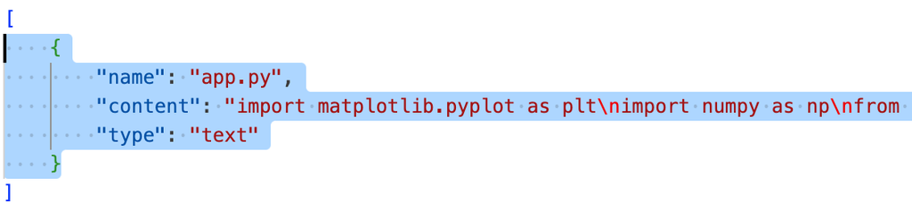

## Deploying Shinylive apps as static pages

[figure not shown]

[How-To by Rami Krispin](https://github.com/RamiKrispin/shinylive?tab=readme-ov-file#deploy-shinylive-app-on-github-pages)

## Testing the deployed app

[figure not shown]

tidy-intelligence.github.io/pydata-berlin-2025

## Shipping data with Parquet

- **Parquet** = efficient, compressed columnar data format
- Can be read **in-browser** using PyArrow / Polars
- Ideal for **small datasets** & offline-first apps
- Disadvantage: (potentially public) **static data**

## Example: reading Parquet files

```python
import matplotlib.pyplot as plt
from shiny import App, render, ui

# Import polars to load Parquet
import polars as pl

df = pl.read_parquet("app-parquet/data.parquet")

app_ui = ui.page_sidebar(
    ui.sidebar(ui.input_slider("n", "N", min=0, max=100, value=20)),
    ui.output_plot("histogram"),
    title="Hello, PyData Berlin!",
)


def server(input, output, session):
    @output
    @render.plot
    def histogram():
        # Use data frame instead of generated values
        data = df["values"].to_numpy()
        plt.hist(data, bins=input.n(), density=True)


app = App(app_ui, server)
```

## Files are also encoded in `app.json`

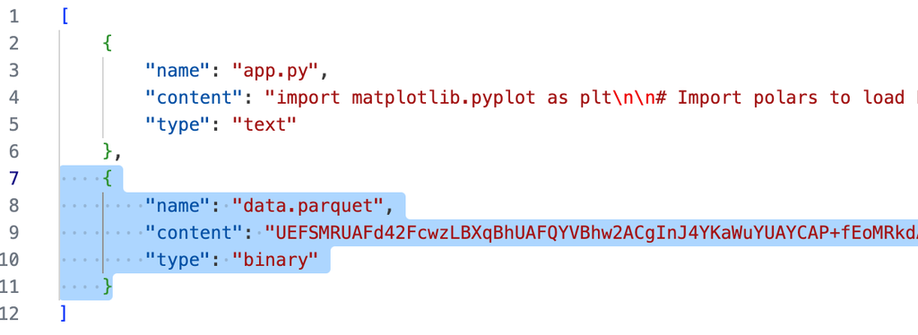

## Optional backend with FastAPI

- Offload **compute** or **storage** tasks to dedicated server
- Handle **authentication**, remote database access, heavy lifting
- Build API endpoints with **FastAPI** as needed
- Disadvantage: authentication may be **complex**

## Example: complex auth & data backend

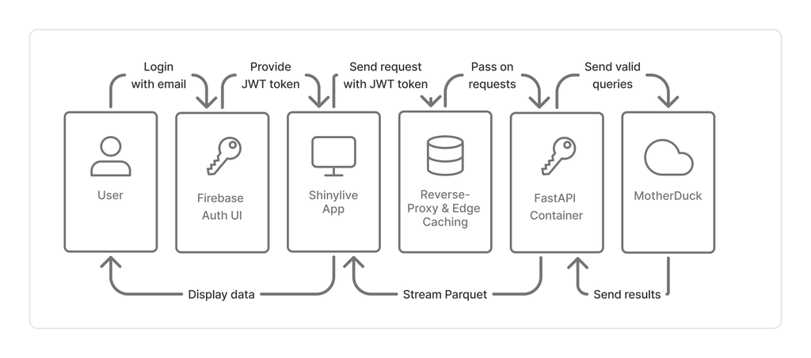

## Design patterns

- **Pure client-side**: when datasets are small, apps are simple
- **Hybrid mode**: add backend for auth, heavy compute, or write access
- **Modularize**: keep server logic stateless
- Use **reactivivty** to simplify UI logic

## Limitations to be aware of

- **Bundle size** (e.g., Pyodide ~3MB, Numpy ~2.5MB, Pandas ~4.1MB)
- Initial **loading time** (but caching helps)
- **Limited packages** (pure Python, no C extensions unless Wasm compiled)
- Browser **memory & performance** constraints

## When to use this stack

✅ **Great for**:

- Dashboards, small data apps (potentially behind firewalls)
- Education / demos / data exploration
- Lightweight deployments (e.g., GitHub Pages)

🚫 **Not ideal for**:

- Real-time streaming or huge datasets
- Complex authentication or role-based access control

## Key takeaways

- Wasm + Shinylive opens new doors for **Python in the browser**
- **Fully reactive apps** without JavaScript or explicit callbacks
- Efficient **local data** access via **Parquet**
- **Optional FastAPI** services for hybrid models

## Thank You 🙏

[figure not shown]

[Follow on LinkedIn](https://www.linkedin.com/in/christophscheuch/)

[figure not shown]

[GitHub Repo](https://github.com/tidy-intelligence/pydata-berlin-2025)

## Resources

- WebAssembly: [webassembly.org](https://webassembly.org/)
- Shinylive: [shiny.posit.co/py/get-started/shinylive](https://shiny.posit.co/py/get-started/shinylive.html)
- Pyodide: [pyodide.org](https://pyodide.org/)
- Apache Parquet: [parquet.apache.org](https://parquet.apache.org/)
- FastAPI: [fastapi.tiangolo.com](https://fastapi.tiangolo.com/)
- Repo: tidy-intelligence/pydata-berlin-2025